# Assignment 3

Kari Roynesdal

9/22/2020

```r
library(tidycensus)
library(tidyverse)
library(ggplot2)
library(extrafont)
library(extrafontdb)
loadfonts(device = "win")
```

# Topic of Interest

I would like to explore the relationship between home ownership status, vacancy status, and race/ethnicity in the census level tract for Suffolk County in Massachusetts. I am using 2010 census data at the county level.

```r
area_vars_2010 <- load_variables(2010, "sf1")
```

# Load Variables

I am interested in looking at the following variables:

1. Whether the tract is urban or rural (categorical)
2. Vacancy status of a parcel (categorical)
3. The majority racial/ethnic identity (categorical)
4. The percent of owner-occupied households (continuous)
5. The percent of white owner-occupied households (continuous)
6. The population of the tract (continuous)
7. The median age of residents (continuous)

```r
vars <- c(tot_hh = "H001001",
          tot_urban_hh = "H002002",
         tot_own_hh = "H016002",
         tot_whiteown_hh = "H016A002",
         vacancy = "H003003",
         tot_pop = "P003001",
         nh_white_pop = "P005003",
         nh_black_pop = "P005004",
         nh_asian_pop = "P005006",
         hispanic_pop = "P005010",
         med_age = "P013001")

Suffolk_tracts <- get_decennial(geography = "tract", variables = vars,
                           state = "MA", county = "Suffolk",
                           output = "wide") %>%
  mutate(urban = (tot_urban_hh == tot_hh) ,
         pct_whiteown = tot_whiteown_hh / tot_own_hh,
         pct_own = tot_own_hh / tot_hh,
         majority_race_eth = case_when(
           nh_white_pop / tot_pop > 0.5 ~ "nh_white",
           nh_black_pop / tot_pop > 0.5 ~ "nh_black",
           nh_asian_pop / tot_pop > 0.5 ~ "nh_asian",
           hispanic_pop / tot_pop > 0.5 ~ "hispanic",
           (nh_white_pop + nh_black_pop + nh_asian_pop + hispanic_pop) /
             tot_pop < 0.5 ~ "other",
           TRUE ~ "None")) %>%
  filter(tot_pop > 0, tot_hh > 0) %>%
  select(GEOID, urban, majority_race_eth,
         pct_whiteown, pct_own, vacancy, tot_pop, med_age)
```

```
## Using Census Summary File 1
```

# Relationship Between Continuous Variables

I want to understand the relationships between my continuous variables, which are Median Age, Total Population, Percent Owner-Occupied Households, and Percent White Owner-Occupied Households. To do so, I will run a correlation test.

```r
correlation1 <- cor.test(Suffolk_tracts$med_age, Suffolk_tracts$pct_own)
correlation1
```

```
##
##  Pearson's product-moment correlation
##
## data:  Suffolk_tracts$med_age and Suffolk_tracts$pct_own
## t = 16.492, df = 195, p-value < 2.2e-16
## alternative hypothesis: true correlation is not equal to 0
## 95 percent confidence interval:
##  0.6978228 0.8159167
## sample estimates:
##       cor
## 0.7631693
```

The relationship between median age and home ownership has a significant and strong positive correlation at a 95% confidence interval.

```r
correlation2 <- cor.test(Suffolk_tracts$tot_pop, Suffolk_tracts$pct_own)
correlation2
```

```
##
##  Pearson's product-moment correlation
##
## data:  Suffolk_tracts$tot_pop and Suffolk_tracts$pct_own
## t = -0.68986, df = 195, p-value = 0.4911
## alternative hypothesis: true correlation is not equal to 0
## 95 percent confidence interval:
##  -0.18784172  0.09108229
## sample estimates:
##         cor
## -0.04934169
```

```r
correlation3 <- cor.test(Suffolk_tracts$tot_pop, Suffolk_tracts$med_age)
correlation3
```

```
##
##  Pearson's product-moment correlation
##
## data:  Suffolk_tracts$tot_pop and Suffolk_tracts$med_age
## t = -2.7523, df = 195, p-value = 0.006476
## alternative hypothesis: true correlation is not equal to 0
## 95 percent confidence interval:
##  -0.32440448 -0.05507161
## sample estimates:
##        cor
## -0.1933785
```

The relationship between total population and median age has a weak but statistically significant negative correlation at a 95% confidence interval.

```r
correlation4 <- cor.test(Suffolk_tracts$med_age, Suffolk_tracts$pct_whiteown)
correlation4
```

```
##
##  Pearson's product-moment correlation
##
## data:  Suffolk_tracts$med_age and Suffolk_tracts$pct_whiteown
## t = 3.6441, df = 194, p-value = 0.0003444
## alternative hypothesis: true correlation is not equal to 0
## 95 percent confidence interval:
##  0.1171139 0.3797919
## sample estimates:
##       cor
## 0.2531121
```

# Graphing Strongest + Weakest Correlations

I am interested in my strongest correlation, median age and percent home ownership, and my weakest correlation, total population and percent home ownership. I will graph both of these correlations below.

Median Age + Percent Home Ownership

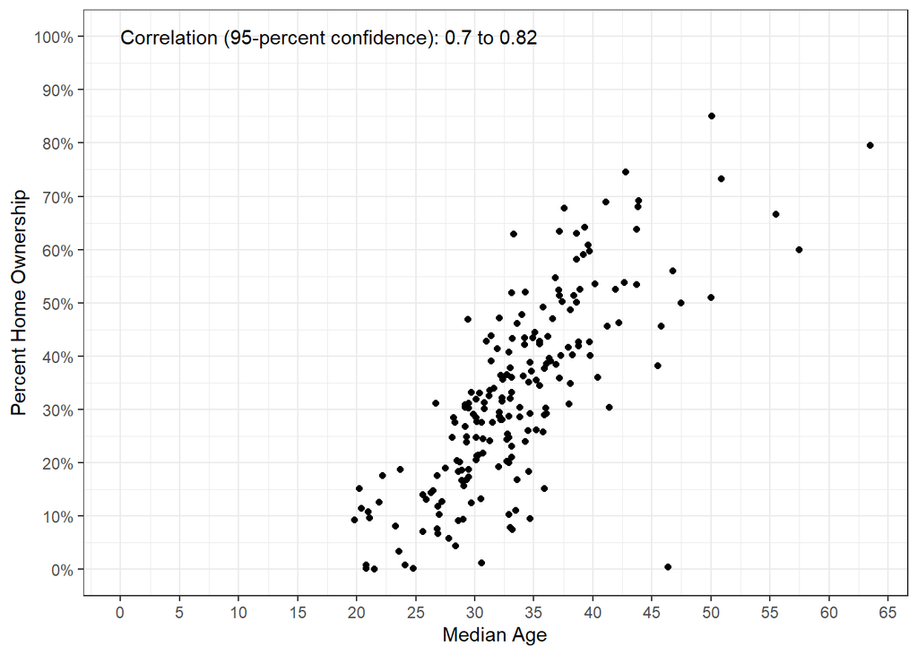

```r
ggplot(Suffolk_tracts,
       aes(x = med_age,
           y = pct_own)) +
  geom_point() +
  scale_x_continuous(name = "Median Age",
                     breaks = seq(0, 100, by = 5),
                     labels = paste(seq(0, 100, by = 5), sep = "")) +
  scale_y_continuous(name = "Percent Home Ownership",
                     breaks = seq(0, 1, by = 0.1),
                     labels = paste(seq(0, 100, by = 10), "%", sep = "")) +
   theme(plot.title = element_text(family = "Garamond",
                             size = 20),
        axis.title = element_text(family = "Garamond"),
        axis.text = element_text(family = "Garamond",
                             size = 5),
        legend.title = element_text(family = "Garamond", face = "bold"),
        legend.text = element_text(family = "Garamond" )) +
  annotate(geom = "text", x = 0, y = 1,
           label = paste("Correlation (95-percent confidence):",
                         prettyNum(correlation1$conf.int[1], digits = 2),
                         "to",
                         prettyNum(correlation1$conf.int[2], digits = 2)),
           hjust = 0) +
  theme_bw()
```

Total Population + Percent Home Ownership

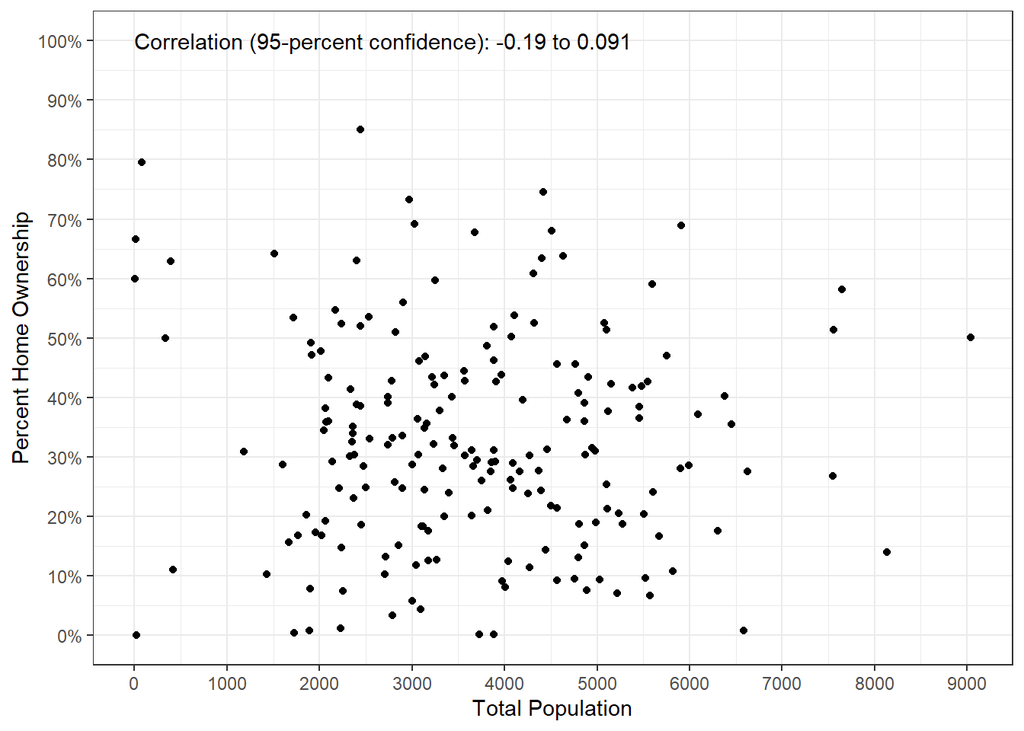

```r
ggplot(Suffolk_tracts,
       aes(x = tot_pop,
           y = pct_own)) +
  geom_point() +
  scale_x_continuous(name = "Total Population",
                     breaks = seq(0, 10000, by = 1000),
                     labels = paste(seq(0, 10000, by = 1000), sep = "")) +
  scale_y_continuous(name = "Percent Home Ownership",
                     breaks = seq(0, 1, by = 0.1),
                     labels = paste(seq(0, 100, by = 10), "%", sep = "")) +
   theme(plot.title = element_text(family = "Garamond",
                             size = 20),
        axis.title = element_text(family = "Garamond"),
        axis.text = element_text(family = "Garamond",
                             size = 5),
        legend.title = element_text(family = "Garamond", face = "bold"),
        legend.text = element_text(family = "Garamond" )) +
  annotate(geom = "text", x = 0, y = 1,
           label = paste("Correlation (95-percent confidence):",
                         prettyNum(correlation2$conf.int[1], digits = 2),
                         "to",
                         prettyNum(correlation2$conf.int[2], digits = 2)),
           hjust = 0) +
  theme_bw()
```

We can clearly see through these two scatterplots that there is a clearer linear relationship between Percent Home Ownership and Median Age, than Percent Home Ownership and Total Population.

# Relationship Between Categorical Variables

I want to understand the relationship between two categorical variables, which are Majority Race/Ethnicity and Vacancy status. To do so, I will run a chi square test.

```r
chi_sq <- chisq.test(Suffolk_tracts$majority_race_eth, Suffolk_tracts$vacancy)
chi_sq
```

```
##
##  Pearson's Chi-squared test
##
## data:  Suffolk_tracts$majority_race_eth and Suffolk_tracts$vacancy
## X-squared = 607.48, df = 564, p-value = 0.09986
```

Because my p-value is not less than 0.05, it seems the correlation between vacancy status and majority race/ethnicity is not statistically significant.

# Relationship Between Continuous + Binary Variable

I want to understand the relationships between my continuous variables, such as median age and percent home ownership, and binary variables such as vacancy status and majority race/ethnicity. To do so, I will run a two sample t-test.

```r
difference1 = t.test(Suffolk_tracts$majority_race_eth == "TRUE", Suffolk_tracts$med_age)

difference1
```

```
##
##  Welch Two Sample t-test
##
## data:  Suffolk_tracts$majority_race_eth == "TRUE" and Suffolk_tracts$med_age
## t = -70.241, df = 196, p-value < 2.2e-16
## alternative hypothesis: true difference in means is not equal to 0
## 95 percent confidence interval:
##  -34.52720 -32.64133
## sample estimates:
## mean of x mean of y
##   0.00000  33.58426
```

```r
difference2 = t.test(Suffolk_tracts$majority_race_eth == "TRUE", Suffolk_tracts$tot_pop)

difference2
```

```
##
##  Welch Two Sample t-test
##
## data:  Suffolk_tracts$majority_race_eth == "TRUE" and Suffolk_tracts$tot_pop
## t = -32.929, df = 196, p-value < 2.2e-16
## alternative hypothesis: true difference in means is not equal to 0
## 95 percent confidence interval:
##  -3880.539 -3441.989
## sample estimates:
## mean of x mean of y
##     0.000  3661.264
```

```r
difference3 = t.test(Suffolk_tracts$majority_race_eth == "TRUE", Suffolk_tracts$pct_own)

difference3
```

```
##
##  Welch Two Sample t-test
##
## data:  Suffolk_tracts$majority_race_eth == "TRUE" and Suffolk_tracts$pct_own
## t = -25.687, df = 196, p-value < 2.2e-16
## alternative hypothesis: true difference in means is not equal to 0
## 95 percent confidence interval:
##  -0.3497259 -0.2998544
## sample estimates:
## mean of x mean of y
## 0.0000000 0.3247902
```

```r
difference4 = t.test(Suffolk_tracts$vacancy == "TRUE", Suffolk_tracts$med_age)

difference4
```

```
##
##  Welch Two Sample t-test
##
## data:  Suffolk_tracts$vacancy == "TRUE" and Suffolk_tracts$med_age
## t = -70.241, df = 196, p-value < 2.2e-16
## alternative hypothesis: true difference in means is not equal to 0
## 95 percent confidence interval:
##  -34.52720 -32.64133
## sample estimates:
## mean of x mean of y
##   0.00000  33.58426
```

```r
difference5 = t.test(Suffolk_tracts$vacancy == "TRUE", Suffolk_tracts$tot_pop)

difference5
```

```
##
##  Welch Two Sample t-test
##
## data:  Suffolk_tracts$vacancy == "TRUE" and Suffolk_tracts$tot_pop
## t = -32.929, df = 196, p-value < 2.2e-16
## alternative hypothesis: true difference in means is not equal to 0
## 95 percent confidence interval:
##  -3880.539 -3441.989
## sample estimates:
## mean of x mean of y
##     0.000  3661.264
```

```r
difference6 = t.test(Suffolk_tracts$vacancy == "TRUE", Suffolk_tracts$pct_own)

difference6
```

```
##
##  Welch Two Sample t-test
##
## data:  Suffolk_tracts$vacancy == "TRUE" and Suffolk_tracts$pct_own
## t = -25.687, df = 196, p-value < 2.2e-16
## alternative hypothesis: true difference in means is not equal to 0
## 95 percent confidence interval:
##  -0.3497259 -0.2998544
## sample estimates:
## mean of x mean of y
## 0.0000000 0.3247902
```

For all my variables, it seems that:

Vacancy Status and Percent Home Ownership = significant, weak correlation

Vacancy Status and Total Population = significant, weak correlation

Vacancy Status and Median Age = significant, extremely weak correlation

Majority Race Ethnicity and Median Age = significant, extremely weak correlation

Majority Race Ethnicity and Total Population = significant, weak correlation

Majority Race Ethnicity and Percent Home Ownership = significant, weak correlation

I am curious what the violin plot looks like for Majority Race Ethnicity and Percent Home Ownership:

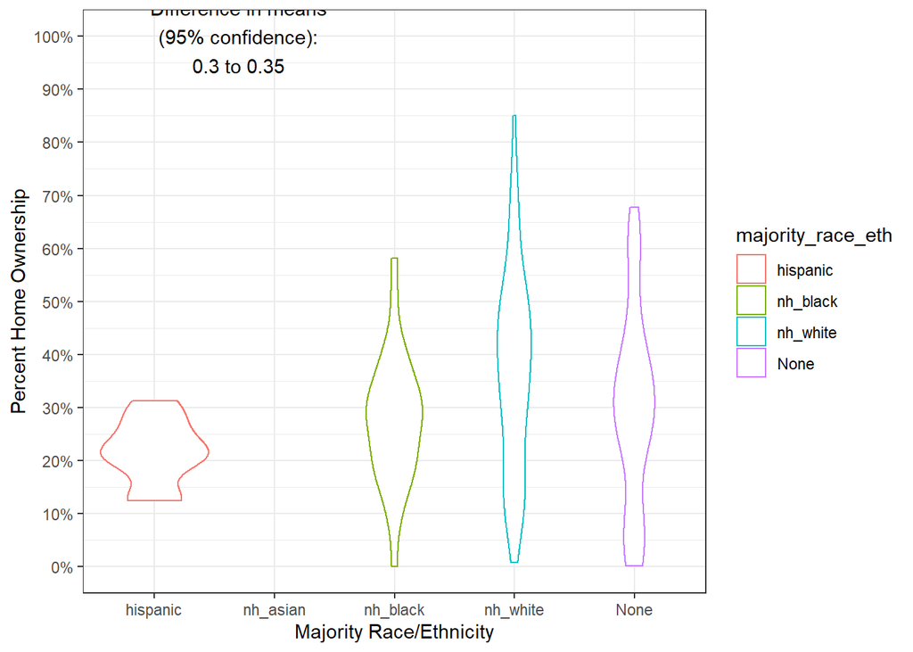

```r
ggplot(Suffolk_tracts,
       aes(x = majority_race_eth,
           y = pct_own,
           color = majority_race_eth)) +
  geom_violin() +
  scale_x_discrete(name = "Majority Race/Ethnicity",
                   ) +
  scale_y_continuous(name = "Percent Home Ownership",
                     breaks = seq(0, 1, by = 0.1),
                     labels = paste(seq(0, 100, by = 10), "%", sep = "")) +
   theme(plot.title = element_text(family = "Garamond",
                             size = 20),
        axis.title = element_text(family = "Garamond"),
        axis.text = element_text(family = "Garamond",
                             size = 5),
        legend.title = element_text(family = "Garamond", face = "bold"),
        legend.text = element_text(family = "Garamond" )) +
  annotate(geom = "text", x = 1.7, y = 1,
           label = paste("Difference in means\n(95% confidence):\n",
                         prettyNum(abs(difference3$conf.int[2]),
                                   digits = 2), " to ",
                         prettyNum(abs(difference3$conf.int[1]),
                                   digits = 2),
                         sep = "")) +
  theme_bw()
```

# Relationship Between Three-Level Categorical Variable and Continuous Variable

For looking at my three-level categorical variables and continuous variables, I will use an ANOVA test.

```r
anova1 <- aov(vacancy ~ pct_own, data = Suffolk_tracts)

summary(anova1)
```

```
##              Df  Sum Sq Mean Sq F value Pr(>F)
## pct_own       1     115     115   0.019  0.889
## Residuals   195 1153466    5915
```

```r
anova2 <- aov(vacancy ~ med_age, data = Suffolk_tracts)

summary(anova2)
```

```
##              Df  Sum Sq Mean Sq F value Pr(>F)
## med_age       1    1347    1347   0.228  0.634
## Residuals   195 1152234    5909
```

```r
anova3 <- aov(vacancy ~ tot_pop, data = Suffolk_tracts)

summary(anova3)
```

```
##              Df Sum Sq Mean Sq F value   Pr(>F)
## tot_pop       1 183475  183475   36.88 6.45e-09 ***
## Residuals   195 970106    4975
## ---
## Signif. codes:  0 '***' 0.001 '**' 0.01 '*' 0.05 '.' 0.1 ' ' 1
```

Findings:

Vacancy/Percent Ownership: Not Significant

Vacancy/Median Age: Not Significant

Vacancy/Total Population: Significant